# Unit 1: Data Literacy and Political Science

# 1 Introduction

Welcome to Module 1. Many of you may be encountering data, statistics, and political science research methods for the very first time. That is perfectly fine—these modules are meant to guide you step by step, with clear explanations and simple examples.

In this module, we begin with a simple but important question: **Why does data matter in political science?** Political science is not only about debating ideas, history, and institutions—it is also about **evidence**. Evidence allows us to move beyond opinion and speculation toward systematic analysis of how politics actually works.

Throughout this course, we will introduce AI tools and other online resources. These can support your learning by helping you practice, explore, and check your understanding. However, your own judgment and critical thinking are what matter most. Data literacy means not only working with data but also questioning the way information is presented—whether in scholarly articles, news reports, or outputs generated by AI tools.

## 1.1 Why Data Literacy?

There are at least three reasons why data literacy is essential to understand politics:

1. **Understanding the political world**: Democracies, authoritarian regimes, international organizations, and social movements all generate large amounts of information. Being able to read and evaluate these numbers—such as election turnout, public opinion polls, or trade statistics—allows you to better understand contemporary debates.
2. **Evaluating claims**: Politicians, media outlets, and advocacy groups often make claims backed (or seemingly backed) by “data.” Without data literacy, it is easy to be persuaded by misleading numbers or biased presentations. Armed with data literacy, you can critically evaluate whether those claims are truly supported by evidence.
3. **Producing knowledge**: To engage in political science research, scholars build datasets, apply methods, and draw conclusions about how the world works. As a student, developing the skills to engage with these practices allows you to move from consumer to producer of knowledge.

In simple terms, developing data literacy means gaining the ability to step back and ask critical questions about the information you see. It allows you to question bold claims, recognize when numbers might be misleading, and engage in political debates using evidence rather than opinion. With these skills, you will be able to participate more thoughtfully in discussions about politics, policies, and society.

### 1.1.1 Conceptualization and Measurement

Before diving into specific data examples, recall two foundational concepts in political science research:

- **Conceptualization**: Defining what we mean by abstract political ideas. For example, what does “democracy” mean? Is it only about free and fair elections, or does it also require civil liberties and accountability?
- **Measurement**: Turning those abstract concepts into observable indicators. For democracy, we might measure it through election monitoring reports, indexes like V-Dem or Freedom House, or survey data on citizens’ rights.

Without careful conceptualization and measurement, our data cannot meaningfully reflect the political world. This is why political scientists spend so much effort debating definitions and indicators.

## 1.2 Story: NGO and Democracy Promotion

Imagine you are reading the news and come across a story: in 2016, China introduced a new law requiring all foreign NGOs to register with the Ministry of Public Security ([BBC report](https://www.bbc.com/news/world-asia-china-36157052)). At first, this seems like just one political event. But in the classroom, we can turn this into a story about data creation. To study NGOs systematically, scholars have to decide: how do we define “NGO activity”? How do we measure whether a government is supportive or restrictive? One influential study (Dupuy, Ron, & Prakash 2015, *Social Science Research*) built a dataset by collecting reports from many countries on how NGOs were regulated. This meant coding laws, restrictions, and levels of freedom across different political systems.

We can start with a single news story and turn it into data by creating clear rules and categories. Once it is part of a larger dataset, we can compare China not only to itself over time but also to many other countries. This kind of comparison shows patterns — for example, authoritarian governments often restrict NGOs, while democracies are more likely to allow them to operate freely. The story gains power when it is connected to systematic evidence.

### 1.2.1 IGO Participation by Country

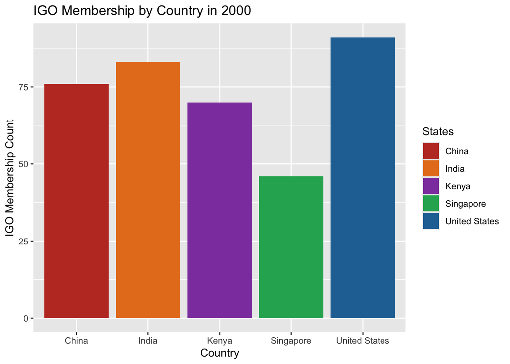

This bar chart shows how many international organizations each country belongs to. Countries with high levels of IGO (intergovernmental organization) participation often face greater international expectations regarding their treatment of NGOs and democratic practices. This connects back to the China example: maintaining extensive international ties while restricting NGOs at home illustrates the tension between domestic control and global integration.

### 1.2.2 IGO Participation Level and Democracy

[figure not shown]

This line chart tracks how each country’s democracy score (Electoral Democracy Index) has changed over time. Some countries show steady improvement, others remain flat, and some fluctuate. Before looking at whether democracy and IGO membership are related, it helps to see how each country’s democracy trajectory looks on its own.

[interactive chart not shown]

The line chart above tracked democracy over time. This interactive scatter plot lets you see how democracy and IGO membership relate to each other — use the slider to move through the years, or press play to animate.

Each dot is a country. As you move through time, watch how countries trace different paths: some gain both democracy and IGO membership together, while others increase international ties without a matching rise in democracy. Try pausing on a few years and comparing — the relationship isn’t the same for every country.

Together, these plots demonstrate how political scientists transform individual stories into measurable patterns. The NGO case becomes part of a wider picture that links democracy, NGOs, and international cooperation.

**Reflection on NGO and Democracy Promotion**

- Why might governments view NGOs as both helpful and threatening?
- How could we measure the presence or influence of NGOs in a dataset?
- Looking at the plots: what patterns do you notice about IGO participation and democracy over time?
- Do you think higher democracy scores always lead to higher IGO participation levels?

## 1.3 (Optional) Videos

Here are some videos that might help if you learn better through visuals. They are not required, but you may find them useful for reviewing key ideas from this unit or seeing them explained in another way.

[You need data literacy now more than ever – here’s how to master it | Talithia Williams](https://www.youtube.com/watch?v=81vaStxwmD8)

[What are Data and Data Literacy: Study Hall Data Literacy #1: ASU + Crash Course](https://www.youtube.com/watch?v=yhO_t-c3yJY)

## 1.4 Knowledge Check

### Data Literacy Foundations

**1. Data literacy includes questioning how and why information is presented.**

a) True

b) False

**2. Which of the following best describes conceptualization in political science research?**

a) Measuring how often data is collected

b) Defining what abstract ideas like “democracy” or “freedom” actually mean

c) Visualizing concepts through graphs

**3. According to the module, why do political scientists debate definitions and indicators?**

a) Because concepts like democracy can be measured in many valid ways

b) Because they prefer theory over evidence

c) Because they disagree about using statistics in politics

# 2 Understanding Political Data

## 2.1 From Stories to Data Structures

The NGO example and the plots showed how a single event can be turned into measurable evidence. To deepen this idea, we now turn to the structure and meaning of political data. This shift is important for data literacy: single stories become entry points into larger datasets, and those datasets are not just random numbers but carefully designed representations of the political world. To interpret them, we need to ask: Where did the data come from? How was it created? What does it actually measure?

### 2.1.1 Democracy Indexes

There are many different approaches to conceptualizing and measuring democracy, and understanding these measures helps connect stories like the NGO example to broader theme.

For instance, journalists reporting on democracy trends often rely on indexes that summarize many pieces of information into one score ([example: US News coverage](https://www.usnews.com/news/best-countries/articles/2025-03-25/democracy-expert-raises-alarm-about-u-s-trends-under-trump)). These indexes attempt to capture complicated realities—such as the quality of elections, the extent of civil liberties, and the strength of accountability institutions—into numerical scales that can be compared across countries and over time. Some indexes may weigh elections more heavily, while others emphasize freedom of the press or judicial independence. This means that the same country might receive different scores depending on which index you consult, and those differences reflect the choices researchers make about what democracy means and how it should be observed.

Where do these indexes come from? Who collects them? Scholars and reporters often use measures such as:

- **V-Dem (Varieties of Democracy)** – global dataset with dozens of democracy indicators.
- **Freedom House** – annual *Freedom in the World* report categorizing countries as Free, Partly Free, or Not Free.
- **Polity IV Project** – long-running dataset scoring countries on democratic and autocratic characteristics.

These indexes differ in scope and methodology, so it’s important to pay attention to the sources cited in the news you read, especially when making generalizations or claims.

## 2.2 Reading a Codebook

Every dataset should come with a codebook: a document that explains what each variable means, how it is measured, and what its values represent. A full dataset will also include a methodology, which describes how the data was collected, coded, and aggregated. Methodology is essential for research, but here we are focusing on the codebook as the starting point for learning how to read and interpret data.

For this module, we merged two datasets (V-Dem and COW IGO data) to create a practice dataset and its codebook. A codebook typically includes:

- Variable names and labels
- Definitions of the concepts being measured
- Coding rules and sources
- Units of analysis (e.g., country-year)
- Scale and type of measurement

Example variable: `IGO_participation_level` describes the extent of a country’s participation in IGOs. It is an ordinal variable, where higher values indicate higher levels of participation. To illustrate, here is a simple bar plot showing the distribution of IGO participation levels across selected countries:

### 2.2.1 IGO participation level change

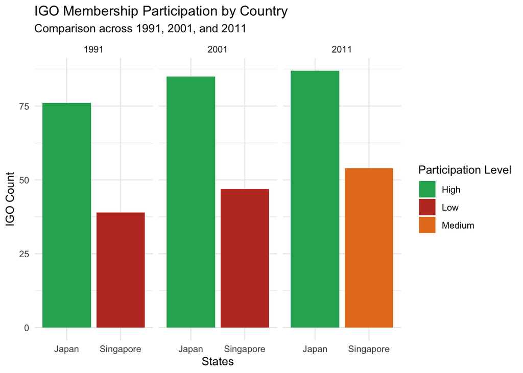

This plot shows how IGO membership breaks down by participation level (Low, Medium, High) for Singapore and Japan across three years. Compare the panels: does the balance between participation levels change over time? How does Japan’s pattern differ from Singapore’s?

**Reflection on Understanding Political Data**

- What is the unit of analysis in the provided codebook? Why does this matter?
- How should we conceptualize and measure gender equality in politics?
- If we examine Richland County spending data, what would be the most appropriate unit of analysis?
- Can we directly compare survey waves collected by different organizations? Why or why not?
- Why is it important to distinguish between different types of data when conducting analysis?

## 2.3 Made vs. Found Data

Political scientists work with two main types of data:

- **Made (manufactured) Data** – collected through surveys or experiments. For example, `v2x_gender` from V-Dem is based on expert survey. The [American National Election Studes](https://electionstudies.org/about-us/history/) a long-running survey program that collects data on voting, public opinion, and political participation in the United States. It provides repeated surveys across different election years, allowing researchers to track change over time while also recognizing that survey design and context can influence responses.
- **Found Data** – administrative records or official statistics. For example, Richland County’s public spending records, or official lists of IGO memberships published by ASEAN or the Singapore Ministry of Foreign Affairs.

Surveys and experiments generate made (manufactured) data, while governments and organizations generate found data. Both are valuable, but each comes with challenges. Made (manufactured) data may reflect researcher choices in survey design, while found data may reflect bureaucratic or political priorities.

### 2.3.1 The Richland County’s Zoo budget

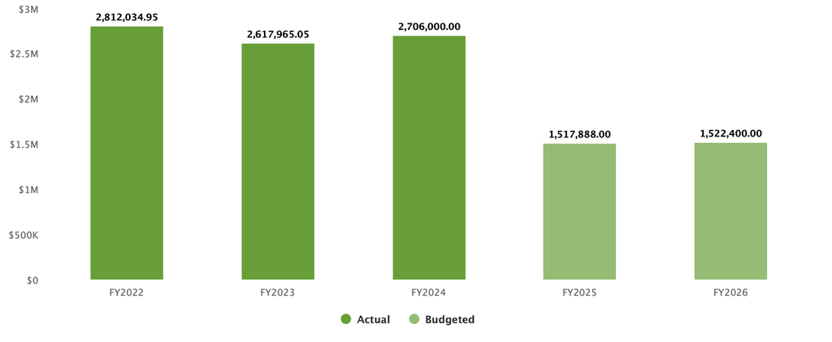

One clear example of found data is the Richland County Zoo and Garden budget. This dataset records yearly spending for the zoo as part of the county’s official budget book. The data were not collected for research, but for fiscal accountability and public transparency. When political scientists use such data, they must adapt administrative categories (like departments or fiscal years) into analytical units that make sense for their research questions.

**Reflection on Made vs. Found Data**

- How is the Richland County Zoo budget different from survey-based data like `v2x_gender`?
- How might coding decisions affect the way data can be analyzed?

## 2.4 (Optional) Videos

Here are some videos that might help if you learn better through visuals. They are not required, but you may find them useful for reviewing key ideas from this unit or seeing them explained in another way.

[How to Collect Data: Study Hall Data Literacy #4: ASU + Crash Course](https://www.youtube.com/watch?v=zGFuj9tF33Q&list=PLNrrxHpJhC8m_ifiOWl1hquDmdgvcviOt&index=5)

[Types of Data: Nominal, Ordinal, Interval/Ratio - Statistics Help](https://www.youtube.com/watch?v=hZxnzfnt5v8)

# 3 Practice: POLI LIT Codebook

Please complete the [POLI LIT Codebook Practice](https://www.edwinachen.com/teaching/poli-lit/practice-codebook) before starting the next section.

# 4 Types of Variables

Below is a picture showing the dataset we talked about earlier (the same one you explored in the codebook). Each **row** represents one observation (a country in a specific year), and each **column** is a variable (such as democracy score, IGO membership, or GDP per capita).  
- Look carefully at the rows and columns: what information do they contain?  
- How could this dataset be presented visually (tables, bar charts, line plots)?  
- In what ways might it help us understand politics?

This section will guide you through the **basic statistical concepts** needed to interpret and use data. First, let’s talk about the **types of variables**.

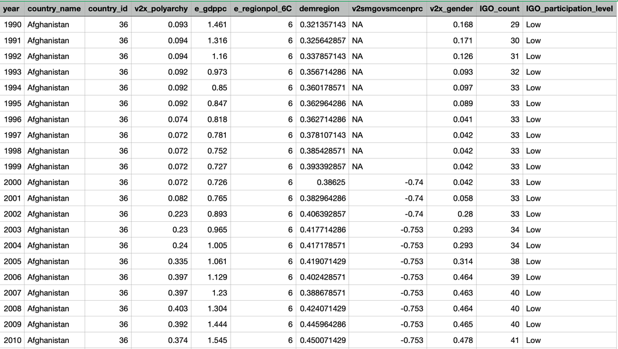

## 4.1 Nominal, Ordinal, Interval, Ratio

Understanding data types is the **first step** in analysis, because it determines which statistical tools are appropriate.

- **Nominal**
  - Definition: Categories with no natural order.
  - Example: *e_regionpol_6C* – each number represents a region (1 = Africa, 2 = Americas, 3 = Asia, etc.).
  - Key point: You can group or count how many countries fall in each region, but it doesn’t make sense to say one region is “greater” or “less” than another.
- **Ordinal**
  - Definition: Categories with a meaningful order, but not evenly spaced.
  - Example: *IGO_participation_level* – coded as Low, Medium, or High depending on how many IGOs a country joins.
  - Key point: You can rank countries from low to high participation, but the jump from “Low” to “Medium” may not represent the same increase as from “Medium” to “High.”
- **Interval**
  - Definition: Ordered, evenly spaced numbers, but without a true zero point.
  - Example: *year* – the calendar year of observation (1990–2015).
  - Key point: The difference between 2000 and 2005 is five years, but “year 0” doesn’t represent the absence of time, so ratios like “twice as many years” don’t make sense.
- **Ratio**
  - Definition: Ordered, evenly spaced numbers, with a true zero point. Ratios are meaningful.
  - Example: GDP per capita.
  - Key point: Because zero represents the absence of GDP, ratios and comparisons make sense—you can say one country’s GDP per capita is twice another’s or calculate meaningful averages.

Other variables in our codebook illustrate the same four types: `country_id` is nominal (a numeric ID code with no meaningful order), `IGO_count` is ratio (a true count of memberships, where zero means no memberships), and `v2x_gender` and `demregion` are interval (index scores with equal spacing but no true zero). Distinguishing between types of data matters because it affects the kinds of analyses we can perform and the conclusions we can draw.

## 4.2 Example: University Enrollment Data

When learning statistics, it helps to begin with something concrete. Consider a dataset that records student enrollment by gender, race, residency, and program level. Such information can be broken into categories and numbers that allow us to see patterns and differences.

This example allows us to review how **different data types** are defined. The table below provides sample variables with their values and a blank column for classifying the data type:

2024 Fall Semester University of South Carolina Political Science Undergraduate Enrollment Demographic

[output not shown]

In this enrollment example, each variable fits a different type. *Gender* and *enrollment status* are nominal because they sort students into categories without order. *Class standing* is ordinal because the categories follow a sequence (freshman → senior), though the “distance” between them isn’t equal. *Enrollment count* is ratio because it is a true number with a meaningful zero—742 students means twice as many as 371. Notice that percentages like “53.1% female” are also ratio data, since zero percent would mean no students at all.

Recognizing whether a variable is nominal, ordinal, interval, or ratio is the first step in choosing the correct statistical tools.

> If you want to more information for USC Enrollment Data, check out this page: [Here](https://sc.edu/about/offices_and_divisions/institutional_research_assessment_and_analytics/uofsc_data_dashboards/enrollment/overview.php)

## 4.3 Knowledge Check

### Variable Basics

**1. Most datasets are organized into rows (observations) and columns (variables).**

a) True

b) False

**2. The variable e_regionpol_6C is ordinal because regions can be ranked.**

a) True

b) False

**3. Why is it important to know the type of a variable?**

a) It determines total sample size.

b) It helps choose proper statistics and graphs.

c) It tells you what color to use in graphs.

**4. Which of the following is an example of a ratio variable?**

a) Region (Africa, Asia, Americas)

b) GDP per capita (logged)

c) Class Standing (Freshman, Sophomore, etc.)

### Data Types & Structure — Quick Check

*Think about each question and write down your ideas before clicking to see a sample answer.*

1. Why is it important to know whether a variable is nominal, ordinal, interval, or ratio?

   Variable type determines which summaries and tests make sense. For example, you can take a mean or run a correlation for ratio/interval data, but not for nominal categories. It also guides plot choice (e.g., bar charts for categories, histograms for numeric data).
2. Why is `e_regionpol_6C` considered nominal, while `IGO_participation_level` is ordinal?

   `e_regionpol_6C` labels regions (Africa, Americas, Asia, etc.) with no natural order—so it’s nominal. `IGO_participation_level` (Low/Medium/High) has a meaningful order but uneven steps—so it’s ordinal.
3. What does it mean when a dataset has one row per country-year?

   Each observation combines a specific country and a specific year. This lets us compare countries in the same year and track change over time for each country.
4. Using a daily-life example, explain how **interval** differs from **ratio**.

   Interval scales have equal steps but no true zero (e.g., temperature °C—20°C isn’t “twice as hot” as 10°C). Ratio scales have a true zero (e.g., income $0 means none; $20 is twice $10).

# 5 Democracy Indexes as Comparative Data

Just as USC publishes enrollment data, political scientists publish measures of democracy. Beyond V-Dem, some well-known indexes include:

- **Polity IV Project** ([link](https://www.systemicpeace.org/polityproject.html))
- **Economist Intelligence Unit’s Democracy Index** ([link](https://www.eiu.com/n/campaigns/democracy-index-2024/))

Researchers use these indexes to ask big questions, such as: [*Are democracies really better governed?*](https://www.annualreviews.org/content/journals/10.1146/annurev-polisci-060820-060910) which reviews studies comparing how democracies and autocracies perform. The authors explain that democracies often have advantages in accountability and citizen participation, which can lead to better governance—though the outcomes are not always straightforward or guaranteed.

Their article shows that political scientists build on each other’s work over decades to see whether democracy really improves outcomes, and they also point out the limits—such as the fact that many other factors like economic development or institutions can shape governance quality.

## 5.1 Correlation: Do Democracies Promote Gender Equality?

One of the simplest and most widely used tools in political science is **correlation**—a way of measuring how closely two variables move together. But just because two factors show a strong relationship does not mean that one causes the other. For example, ice cream sales and sunburn cases both rise in the summer, but eating ice cream does not cause sunburn—the underlying factor is hot weather.

V-Dem researchers examine whether democracies are correlated with higher levels of gender equality ([policy brief](https://www.v-dem.net/media/publications/pb_37_aAwHJrz.pdf)). They note that many different factors - that democracies often promote gender equality through education, free elections, and stronger representation of women in politics. Tools like gender quotas and female leadership can help, but the impact is greater when institutions are truly democratic. By contrast, some autocracies use quotas mainly for image or legitimacy, without real reforms.

Researchers often build on each other’s work or combine different methods to identify mechanisms—such as whether specific policies, institutional practices, or cultural norms explain why democracies are linked with greater gender equality.

### 5.1.1 Correlation between Democracy and Gender Equality in 2014

[interactive chart not shown]

**Exploring Relationships Between Variables**

Hover over any dot to see which country it represents. Can you find any surprises — countries that don’t fit the general trend?

### 5.1.2 How to Read the Plot

As you look at the line plot, ask yourself:

- Do countries with **higher democracy scores** also tend to have **higher gender equality**?
- Are the points **close together** (showing a strong relationship) or **scattered** (showing a weaker one)?
- Does the pattern rise upward (positive correlation) or slope downward (negative correlation)?

*Tip:* A line or scatter plot like this helps visualize whether two variables “move together,” but it **does not tell us why**.

### 5.1.3 Think About the Story Behind the Data

Even if we see a strong correlation, that doesn’t mean one variable *causes* the other.  
For example, ice cream sales and sunburns both increase in summer, but ice cream doesn’t cause sunburn—**a third factor (temperature)** explains both.

Similarly, democracies might have more gender equality, but other factors—like **education, wealth, culture, or policy**—could also play a role.

**Questions to Consider**

- What are the **limitations** of saying “democracy promotes gender equality”?
- Could other factors (e.g., economic development, education, or culture) influence the relationship?
- Are there countries that don’t fit the general trend? What might explain those cases?

## 5.2 (Optional) Videos

Here are some videos that might help if you learn better through visuals. They are not required, but you may find them useful for reviewing key ideas from this section or seeing them explained in another way.

[Correlation vs. Causation – Crash Course Statistics](https://www.youtube.com/watch?v=GtV-VYdNt_g)

[The danger of mixing up causality and correlation: Ionica Smeets at TEDxDelft](https://www.youtube.com/watch?v=8B271L3NtAw)

# 6 Moving Toward Descriptive Statistics

So far, we’ve looked at how political data is structured, what variables mean, and how democracy indexes work. Now let’s go further — instead of just looking at individual countries or plots, we’ll use numbers to summarize what’s happening across many countries at once.

Descriptive statistics give us a snapshot of the data. They answer questions like: What’s the typical democracy score? How much do countries differ? Is the data balanced, or are some values more common than others?

## 6.1 Why Descriptive Statistics?

Descriptive statistics help us go beyond noticing patterns — they let us ask whether those patterns are consistent, representative, and meaningful. Just like enrollment data or public opinion polls, knowing the average, median, and spread gives us a clearer picture of what’s really happening.

Let’s start with a visual. The histogram below shows how Gender Equality Index scores are distributed across all countries in 2014.

### 6.1.1 Distribution of Gender Equality

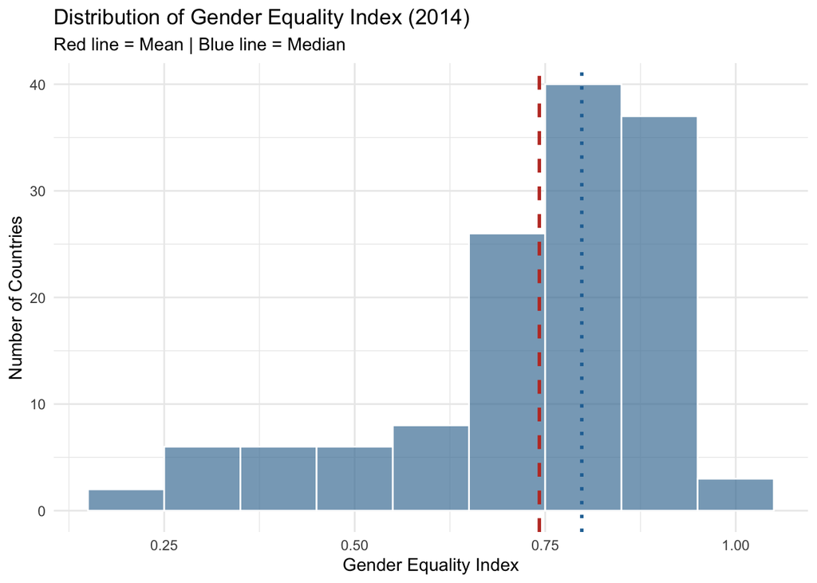

**Reading the plot:**

Focus on: where most countries cluster, whether the distribution is balanced or lopsided, and how close the mean and median are to each other. When they’re close, the data is roughly balanced. When they’re apart, something is pulling the average in one direction.

### 6.1.2 (Optional) Video

[Mean, Median, and Mode: Measures of Central Tendency: Crash Course Statistics #3](https://www.youtube.com/watch?v=kn83BA7cRNM)

[The Shape of Data: Distributions: Crash Course Statistics #7](https://www.youtube.com/watch?v=bPFNxD3Yg6U)

## 6.2 Central Tendency — What’s Typical?

Three measures help us describe what’s “typical” in a dataset:

- **Mean (average):** Add up all values and divide by the number of countries. Shows the overall level — but can be pulled by extreme values.
- **Median:** The middle value when all countries are ordered from lowest to highest. Not affected by outliers, so it often gives a better sense of a “typical” country.
- **Mode:** The most common value. In a histogram, it’s the tallest bar — where the most countries cluster.

The table below shows these measures for both EDI and Gender Equality across all countries in 2014.

### 6.2.1 Summary Statistics: All Countries, 2014

Summary Statistics for EDI and Gender Equality (2014)

| Variable | Mean | Median | SD | Min | Max | N |
| --- | --- | --- | --- | --- | --- | --- |
| EDI (v2x_polyarchy) | 0.5553259 | 0.568 | 0.2531814 | 0.043 | 0.923 | 135 |
| Gender Equality (v2x_gender) | 0.7422836 | 0.798 | 0.1819070 | 0.159 | 0.958 | 134 |

Look at the mean and median columns. When they’re close together, the distribution is roughly balanced. When the mean is noticeably higher or lower than the median, it tells you the data is being pulled by extreme values on one side.

### 6.2.2 Summary Statistics by Region, 2014

Breaking the data down by region reveals patterns that a global average would hide.

Regional Summary Statistics for EDI (2014)

| e_regionpol_6C | Mean_EDI | Median_EDI | SD_EDI | Min_EDI | Max_EDI | N_EDI |
| --- | --- | --- | --- | --- | --- | --- |
| Asia and Pacific | 0.4641667 | 0.4450 | 0.2251928 | 0.085 | 0.834 | 18 |
| Eastern Europe and Central Asia | 0.5575926 | 0.6440 | 0.2587311 | 0.144 | 0.883 | 27 |
| Latin America and Caribbean | 0.6269412 | 0.6180 | 0.1769161 | 0.317 | 0.892 | 17 |
| Sub-Saharan Africa | 0.4467778 | 0.4725 | 0.1816949 | 0.069 | 0.753 | 36 |
| The Middle East and North Africa | 0.3318571 | 0.2970 | 0.2090605 | 0.043 | 0.745 | 14 |
| Western Europe and North America | 0.8770000 | 0.8810 | 0.0318847 | 0.782 | 0.923 | 23 |

Regional Summary Statistics for Gender Equality Index (2014)

| e_regionpol_6C | Mean_Gender | Median_Gender | SD_Gender | Min_Gender | Max_Gender | N_Gender |
| --- | --- | --- | --- | --- | --- | --- |
| Asia and Pacific | 0.6881111 | 0.6755 | 0.1066230 | 0.483 | 0.898 | 18 |
| Eastern Europe and Central Asia | 0.7926667 | 0.8380 | 0.1479342 | 0.377 | 0.946 | 27 |
| Latin America and Caribbean | 0.7697059 | 0.8000 | 0.1112215 | 0.412 | 0.892 | 17 |
| Sub-Saharan Africa | 0.6860556 | 0.7470 | 0.1820884 | 0.159 | 0.862 | 36 |
| The Middle East and North Africa | 0.5140000 | 0.4220 | 0.2217893 | 0.201 | 0.874 | 13 |
| Western Europe and North America | 0.9223043 | 0.9290 | 0.0295780 | 0.846 | 0.958 | 23 |

> The discrepancy in the total number of observations arises from the exclusion of cases containing missing (‘NA’) values.

**Question:** Compare the mean of EDI and Gender Equality across regions. Which regions score highest on both? Are there regions where one is high but the other is low?

## 6.3 Spread — How Much Do Countries Differ?

Knowing the average is useful, but it doesn’t tell us whether most countries are similar or wildly different. That’s where **spread** comes in.

Let’s start with democracy. The histogram below shows how EDI scores are distributed across all countries in 2014.

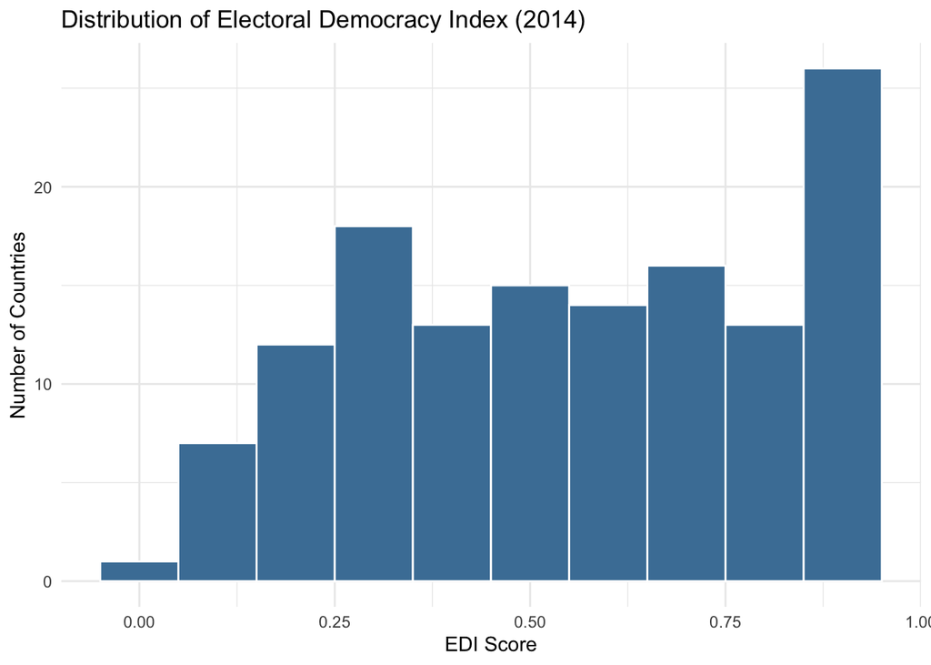

- **X-axis:** EDI score (0 to 1)
- **Y-axis:** How many countries fall in each score range
- The tallest bar shows where most countries cluster — this is the **mode**

Notice that countries don’t pile up neatly in the middle. Some cluster at the low end, others at the high end. Democracy isn’t evenly distributed across the world.

### 6.3.1 GDP per Capita: When the Average Is Misleading

Now let’s look at a variable where spread matters even more: **GDP per capita** — how much economic output each person in a country would receive on average. In this dataset, values are in thousands of USD.

[interactive chart not shown]

Hover over the bars to see how many countries fall in each range. Notice two things:

- **Most countries are clustered on the left**, with GDP per capita below $20,000. Only a handful of wealthy countries stretch out to the right.
- **The red line (mean) sits to the right of the blue line (median).** A few very wealthy countries drag the average up — even though most countries have much lower incomes.

This is called a **skewed distribution** — the data is lopsided rather than balanced. Compare this to the EDI histogram above, where scores are more spread out across the full range.

When data is skewed, the mean can be misleading. The median gives a better sense of what a “typical” country looks like, because it isn’t pulled by the extremes. This is why political scientists don’t just report the mean — they also check the shape of the distribution and whether the mean and median tell different stories.

**Questions to consider:**

- Why might GDP per capita be skewed while democracy scores are more spread out?
- If you were writing a report on global wealth, would you use the mean or the median? Why?
- Can you think of other political or economic variables that might be skewed like this?

## 6.4 Understanding Spread and Variation

Now that we’ve seen what spread looks like visually, here are the key measures for describing it:

- **Range:** The distance between the highest and lowest values. It gives a quick sense of how widely countries differ. Example: In 2014, EDI ranged from 0.04 to 0.92, while GDP per capita ranged from about $776 to $95,278.
- **Variance:** Measures how far each country sits from the mean, on average. A small variance means countries are similar; a large variance means big differences.
- **Standard Deviation (SD):** The square root of variance, in the same units as the data. SD tells you how tightly values cluster around the mean. A small SD = tight cluster; a large SD = wide spread.

### 6.4.1 Key Concepts Reference

| Concept | What It Tells You | Where to Look |
| --- | --- | --- |
| **Mean** | The overall average level | Summary table or distribution plot (red line) |
| **Median** | The “typical” case — the middle value | Summary table or distribution plot (blue line) |
| **Mode** | The most common value | Histogram — tallest bar |
| **Range** | How far apart the highest and lowest values are | Summary table (Min and Max) |
| **Variance** | How much countries differ from the mean overall | Summary table |
| **Standard Deviation** | Like variance, but in the original units — how tightly values cluster | Summary table |

## 6.5 Recap: From Description to Inference

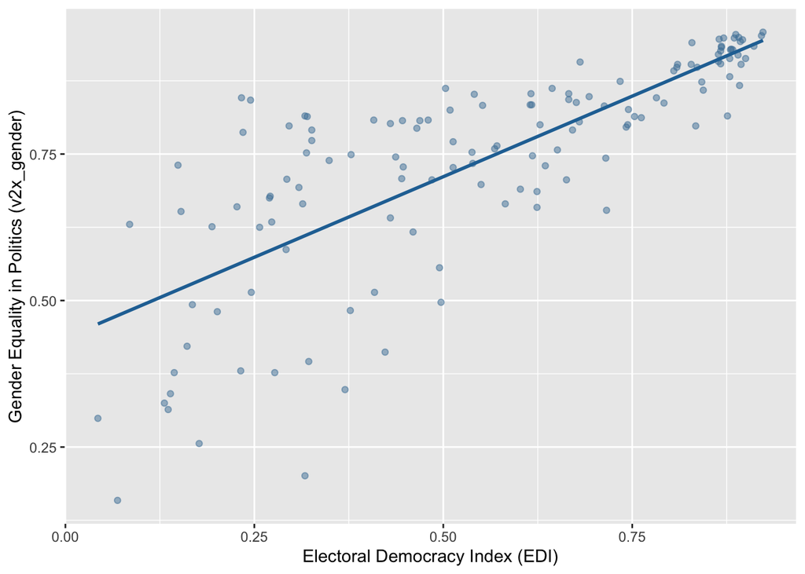

**Exploring Relationships Between Variables**

This plot shows the relationship between **democracy** and **gender equality** using our practice dataset.

Even when a correlation looks clear, it doesn’t tell the whole story. To dig deeper, you could consider the following:

- How consistent is the relationship across different regions or income levels?
- Are there any outliers—countries that don’t fit the overall trend? Which ones?
- Does the pattern look strong and stable, or could it be shaped by a few extreme cases?
- Examine how the relationship changes over time with a line plot or trend chart.

In this unit, you’ve learned to describe data using central tendency (mean, median), spread (range, variance, standard deviation), and distribution shape (balanced vs. skewed). These are the building blocks of data analysis.

The next step — which we’ll cover in the Pre-Unit Lecture — is **statistical inference**: using sample data to ask whether the patterns we see are likely to hold in general or could be due to chance. For example, we saw a positive correlation between democracy and gender equality. But is that relationship strong enough to be meaningful, or could it appear by accident in a different sample of countries?

You don’t need to answer that question yet. For now, the key takeaway is: **descriptive statistics tell you what the data looks like; statistical inference helps you decide what to make of it.**

**Reflection Questions**

- How would you explain the difference between mean, median, and mode to a classmate?
- When is the median more useful than the mean?
- Looking back at the democracy–gender equality correlation from earlier: what other factors might explain that relationship besides democracy itself?

## 6.6 Knowledge check

### Descriptive Statistics

**1. If the variance of GDP per capita is small, this means:**

a) Most countries have similar income levels

b) The mean and median are far apart

c) Most countries have very different income levels.

**2. In a normal distribution, about 68% of observations fall:**

a) Within 1 SD of the mean

b) Within 2 SDs of the mean

c) Beyond 3 SDs of the mean

**3. Which region’s Gender Equality Index scores were most consistent across countries (smallest SD)?**

a) Western Europe and North America

b) Eastern Europe and Central Asia

c) Latin America and Caribbean

**4. The range is unaffected by outliers (countries that have extreme low or high scores).**

a) True

b) False

**5. Which region showed the lowest mean democracy score (EDI) in 2014?**

a) Asia and Pacific

b) Sub-Saharan Africa

c) The Middle East and North Africa

**6. In the 2014 summary-by-region table, which comparison is most appropriate?**

a) Comparing individual country trends over time

b) Predicting 2025 values

c) Comparing average levels and range across regions

**7. A strong correlation between EDI and gender equality proves democracy increases gender equality.**

a) True

b) False

### Discussion — Interpreting EDI & Gender Equality

*Reflect first, then click to reveal a concise sample answer.*

1. If you had to extend this analysis beyond 2014, what two plots or tables would you add first (and why) to see whether the EDI–gender relationship is stable over time?

   1) A **year-by-year correlation table** (and by-region panel) to see whether the EDI–gender correlation rises, falls, or stays steady across years.  
   2) A **time-series line plot** of regional means (EDI and gender on separate panels) to check whether regions move together or diverge.
2. Looking at the gender-equality distribution (2014) with mean/median lines, what does the spacing between those lines tell you about skewness, and why might that matter for interpreting “typical” countries?

   If the **mean > median**, the distribution is **right-skewed**; if the **mean < median**, it’s **left-skewed**. Skewness matters because the mean can be pulled by extremes, while the median reflects the “typical” country.
3. Using the by-region summary table (2014), which region shows the highest consistency in EDI (lowest SD)? What might explain cross-regional differences in average levels and spread?

   **Western Europe & North America** has the lowest SD in EDI (≈0.032), indicating high consistency. Differences may reflect *institutions* (electoral rules, rule of law), *income*, *state capacity*, and *within-region heterogeneity*.
4. Give an example where knowing mean vs. median changes your conclusion about a region’s democracy level. What does that reveal about the distribution?

   In **Eastern Europe & Central Asia**, the mean EDI (~0.558) is below the median (~0.644). The median suggests a *higher typical level* of democracy than the mean implies—consistent with **left skew**.

# 7 Ethical Use of Data

Think about daily life. You might see a news article about a dictator claiming economic success, with charts and numbers that “prove” everything is improving. But you stop and ask yourself: *does this sound right?* This is where the **ethics of data** come in. Data can be powerful, but it can also be misleading when it is selectively presented, manipulated, or taken out of context.

In this section, we look at two perspectives:

1. **When you are presented with data** – Always ask: *Who collected this data? What are their interests? What biases might be shaping the story?*
2. **When you are using data yourself** – Think carefully about your own responsibility: *How will my choices in collecting, cleaning, and analyzing this data affect the story I tell? Am I being transparent and fair?*

## 7.1 When You Are Presented with Data

When you encounter data—whether in a news article, a government report, or a scholarly paper—it can feel like you are looking at something objective and unquestionable. But **data is never neutral.** It always reflects the choices of who collected it, how it was gathered, and how it is presented. To interpret data responsibly, you must learn to recognize the stories behind the numbers.

**Think about possible biases and interests in the story.**  
Ask yourself: *Who benefits from the data being shown in this way?* For example, a government might emphasize declining unemployment rates while ignoring wage stagnation, or an authoritarian leader might highlight “record” agricultural output while concealing food shortages. These selective choices create a narrative that supports particular interests.

**Coverage limits matter.**  
Datasets often exclude important cases. A survey might cover only certain years, omit rural populations, or measure only part of an economy. Each gap shapes the story being told. As the [APSA Ethics Principles](https://www.apsanet.org/Portals/54/diversity%20and%20inclusion%20prgms/Ethics/Final_Principles%20with%20Guidance%20with%20intro.pdf) remind us, researchers must acknowledge the limits of their data and remain transparent about what is included and what is left out.

**Privacy and re-identification risks.**  
Numbers that appear anonymous can still be linked back to individuals if enough detail is present—for example, combining age, gender, and location data. Ethical guidance emphasizes that political scientists should protect confidentiality and anticipate risks of harm to participants, even when formal regulations do not require it.

**Regulation gaps.**  
When rules for data use are weak, powerful actors such as corporations, governments, or platforms may exploit data in ways that threaten fairness, privacy, or even democracy. Predictive policing, voter profiling, or surveillance programs often rely on biased or incomplete datasets. APSA’s ethics statement urges researchers to reflect not only on compliance with laws, but also on their broader responsibility to protect participants and promote integrity in political processes.

**The key** considerations, always pause and ask:

- Where does this data come from?
- What might be missing?
- Whose voices are excluded?
- What risks could emerge if this data were misused?

By developing these habits, you can see beyond the surface of a chart or statistic and begin to evaluate the deeper ethical and political questions tied to data.

## 7.2 When You Are Using Data

As students and researchers, you will not only consume data—you will also produce it, analyze it, and present it to others. This gives you significant responsibility. The stories you tell with data can shape public debates, influence policies, or affect people’s lives. Ethical use of data means recognizing this responsibility and acting with transparency and care.

**Respect participants.**  
When your data involves people, their safety and dignity come first. This means protecting confidentiality, avoiding unnecessary harm, and being mindful of potential re-traumatization when dealing with sensitive topics or vulnerable groups. For example, reporting on survivors of violence requires careful anonymization and sensitivity to context.

**Be transparent.**  
Every dataset is the product of choices: what to collect, how to code, which cases to include, and what methods to apply. Explaining these choices clearly—both in class projects and in published research—allows others to judge the credibility of your work and encourages trust. Transparency also helps others replicate and build on your findings.

**Minimize harm.**  
Consider risks beyond the individual. Publishing data that stigmatizes a community can deepen inequalities or invite discrimination. Ethical practice means actively looking for these risks and making decisions that reduce potential harm wherever possible.

**Check fairness.**  
Be alert to how your methods or interpretations might reinforce bias. Algorithms trained on biased data, selective sampling that overlooks marginalized voices, or framing results in ways that privilege one group all shape unfair outcomes. Strive for fairness by questioning your own assumptions and diversifying the evidence you use.

**Accountability.**  
Your audience, your participants, and the broader public may be influenced by the stories you tell. Accuracy and honesty are non-negotiable. Accountability means owning mistakes, correcting errors, and being clear about the limits of your conclusions.

**Long-term impact.**  
Research findings can echo far beyond the classroom—they can influence policy, shape media coverage, and alter public trust in science. Ethical responsibility requires you to think about how your work might be applied or misused in the future, and to frame your results in ways that balance curiosity with social responsibility.

**The key** consideration: when you use data, always reflect on your role as a storyteller. The choices you make in collection, analysis, and presentation all shape the narrative. Be transparent about your decisions, protect those represented in the data, and consider the broader impact of your work beyond immediate research goals.

Good practice in political science involves **critical reflection, transparency, and accountability**, ensuring that data is used to advance knowledge without causing undue harm.

### 7.2.1 Institutional Review Boards (IRBs) and Data

After learning about individual and professional responsibilities in data ethics, it’s important to see how those responsibilities are enforced in practice. Many countries and universities have systems that provide oversight for research involving people. For example, the **European Union’s Data Act** was created to increase transparency, protect privacy, and ensure that data is used fairly. Policies like this aim to balance innovation with safeguards for individuals and communities.

[figure not shown]

At U.S. universities, this role belongs to the **Institutional Review Board (IRB)** — a committee that reviews research projects to make sure they are ethical, voluntary, and low-risk.

**IRBs highlight key ethical responsibilities:** - Protect participants from unnecessary risks or harm. - Ensure informed consent is obtained whenever possible. - Maintain confidentiality and data security. - Consider long-term consequences of research decisions.

For example, if a student wanted to survey classmates about voting habits, the IRB would check that participation is voluntary, responses are anonymous, and no one feels pressured to take part. At our own university, the [University of South Carolina IRB](https://sc.edu/about/offices_and_divisions/research_compliance/irb/) provides guidelines and approvals for any study involving human subjects. This oversight is not meant to stop research, but to make sure that projects are designed responsibly and ethically.

IRBs differ from national laws such as the European Union’s Data Act, which regulates data use for the general public. IRBs focus specifically on research ethics within universities—turning broad principles into clear checks for academic projects.At USC, the IRB is part of the Office of Research Compliance and is responsible for reviewing all human subjects research to ensure it meets federal regulations and ethical standards. This includes evaluating risk levels, requiring informed consent processes, monitoring confidentiality protections, and ensuring that vulnerable populations receive extra safeguards.

Together with your role as a consumer and producer of data, IRBs show the final layer of responsibility: institutions. This completes the circle—ethical data practice involves individual awareness, professional responsibility, and institutional oversight, all working together to protect participants and strengthen public trust in research.

## 7.3 Key Takeaways

- Data tells a story—but never the whole story. Always ask what’s behind the numbers.
- As a **consumer of data**:stay curious and critical. Question sources, look for bias, and think about what might be missing.
- As a **producer of data**: be transparent about your methods, protect participants, and consider how your analysis might affect real people and communities.
- **Ethical responsibility** goes beyond personal judgment—it includes systems that promote accountability. Institutional Review Boards (IRBs) provide this oversight by ensuring research is voluntary, safe, and respectful of participants.
- Together, these layers—individual awareness, professional integrity, and institutional safeguards—build public trust and help ensure that data in political science is used responsibly and for the public good.

## 7.4 Knowledge check

### Knowledge check

**1. IIf we had no regulation on data use, what might happen?**

a) People’s privacy would be more secure.

b) Data could be misused by companies, governments, or criminals.

c) Researchers would have complete freedom with no risks.

**2. What is a main goal of the Institutional Review Board (IRB)?**

a) To ensure studies are ethical, voluntary, and minimize harm to participants.

b) To publish results for the university.

**3. What is one common risk of relying on “anonymous” datasets?**

a) They may still be linked back to individuals.

b) They eliminate bias.

c) They guarantee fairness.

**4. Which principle means making research steps visible to others?**

a) Autonomy

b) Confidentiality

c) Transparency

**5. Ethical data practice includes considering the long-term impact of research on communities and public trust.**

a) True

b) False

### Short Answer & Discussion Questions

*Think about each question and write down your ideas before clicking to see a sample answer.*

1. If a news article uses a single statistic to make a political point, what questions should you ask?

   Ask about the **source**, **definition**, **denominator**, **time frame**, **measurement**, **uncertainty**, and **bias**. Also consider **alternative indicators** or **interests of the author**.
2. How can researchers minimize harm when working with vulnerable groups?

   Use **informed consent**, assess **risk**, collect minimal data, **protect identities**, and seek **IRB/ethics approval**. Engage respectfully with the community and avoid re-traumatization.
3. How should researchers balance transparency with the need to protect confidentiality?

   Share **methods and code** but limit sensitive data exposure: use **aggregated** or **de-identified** data, add **noise** or **tiered access**, and clearly document redactions.
4. Is it ever acceptable for researchers to use deception in data collection? Why or why not?

   Only when **scientifically necessary**, no alternatives exist, risks are **minimal**, and **participants are debriefed**—subject to **IRB/ethics review**.